# Readme

Ntai Lesenya

October 2020

## Purpose

To Track progress and roadmap of the coding and functions used in the analysis of Us dollar volatility Vs EM and DM equity market performance.

## Loading required packages

Firstly, this function is responsible for loading some core packages needed for the project code:

```r
library(rmsfuns)
pacman::p_load("MTS", "robustbase")
pacman::p_load("tidyverse", "devtools", "rugarch","rmgarch", "forecast", "tbl2xts", "lubridate", "PerformanceAnalytics", "Texevier", "ggthemes")
```

[output not shown]

```r
data <- read_rds ( "data/msci_clean.rds")
```

## Data Section

This section details all the needed code used in the data description section of the paper: The first function below calculates the weekly returns of the msci indices used:

```r
source("code/TRI_Calculation.R")
```

[figure not shown]

```r
WeeklyReturnFunction <- function(data){

  rtn <- data %>% gather(Tickers, TRI, -Date) %>% group_by(Tickers) %>%
  mutate(dlogret = log(TRI) - log(lag(TRI))) %>% mutate(scaledret = (dlogret -
                                                                       mean(dlogret, na.rm = T))) %>% filter(Date > first(Date)) %>%
  ungroup()
Tidyrtn <- rtn


  g <-
ggplot(Tidyrtn) + geom_line(aes(x = Date, y = TRI, colour = Tickers,
                                alpha = 0.5)) + ggtitle("MSCI Returns Series:  EM  & DM Returns") +
  facet_wrap(~Tickers, scales = "free_y") + guides(alpha = FALSE) +
  theme_bw() + scale_color_hue(l = 20) + scale_x_date(labels = scales::date_format("'%y"),
                                                      date_breaks = "2 years") + theme(axis.text = element_text(size = 7)) # However the plot will be inserted in the Appedix in the actual paper for cleanliness

}
```

#Test for Heteroskedasticity in the data using the MV contitional Heteroskedasticity test. This confirms the financial time series characteristic of non-nomarlity and use of GARCH modelling

```r
xts_rtn <- rtn %>% tbl_xts(., cols_to_xts = "dlogret", spread_by = "Tickers")
MarchTest(xts_rtn)
```

```
## Q(m) of squared series(LM test):
## Test statistic:  1597.899  p-value:  0
## Rank-based Test:
## Test statistic:  736.862  p-value:  0
## Q_k(m) of squared series:
## Test statistic:  7212.863  p-value:  0
## Robust Test(5%) :  2234.973  p-value:  0
```

This code design a table for Ticker description (However the table will be inserted in the Appedix in the actual paper for cleanliness):

```r
library(xtable)
des_names <- c("Brazil", "Canada", "Switzerland", "France", "United Kingdom", "India", "Japan", "South Africa", "Taiwan","Egypt", "Bloomberg US Dollar Spot Index")

des_t <- cbind(colnames(xts_rtn), des_names)
colnames(des_t) <- c("Ticker", "Description")

table <- xtable(des_t, caption = "Returns description Table \\label{tab1}")
print.xtable(table,
             # tabular.environment = "longtable",
             floating = TRUE,
             table.placement = 'H',
             # scalebox = 0.4,
             comment = FALSE,
             caption.placement = 'bottom'
)
```

```
## \begin{table}[H]
## \centering
## \begin{tabular}{rll}
##   \hline
##  & Ticker & Description \\
##   \hline
## 1 & MXBR & Brazil \\
##   2 & MXCA & Canada \\
##   3 & MXCH & Switzerland \\
##   4 & MXFR & France \\
##   5 & MXGB & United Kingdom \\
##   6 & MXIN & India \\
##   7 & MXJP & Japan \\
##   8 & MXZA & South Africa \\
##   9 & TAMSCI & Taiwan \\
##   10 & MXEG & Egypt \\
##   11 & BBDXY & Bloomberg US Dollar Spot Index \\
##    \hline
## \end{tabular}
## \caption{Returns description Table \label{tab1}}
## \end{table}
```

## Results

This section details all the needed code used to obatin the results analysed in the PAPER:

## DCC-GARCH modelling

We Apply the following code chunk to calculate the individual volatility series to be used in DCC estimation:

```r
#volatility series modelling
#Firstly for the individual series, a standard univariate GARCH(1,1) modelled to give the H_t (used interchangeably with Sigma for plotting) process to be used in calculating the standardized residual. This are then used in  DCC calculations after.
#dccPre fits the univariate GARCH models to each series of returns
DCCPre <- dccPre(xts_rtn, include.mean = T, p = 0)
```

```
## Sample mean of the returns:  0.001730164 0.001300008 0.00151025 0.001114455 0.00074682 0.001751289 0.0008437061 0.001252042 0.001551825 0.001496483 0.0002118468
## Component:  1
## Estimates:  0.000126 0.104886 0.838511
## se.coef  :  4.8e-05 0.022905 0.03465
## t-value  :  2.643878 4.579193 24.19969
## Component:  2
## Estimates:  1.4e-05 0.169599 0.824702
## se.coef  :  6e-06 0.030503 0.027299
## t-value  :  2.33866 5.560034 30.21033
## Component:  3
## Estimates:  3.7e-05 0.18006 0.77938
## se.coef  :  1.7e-05 0.047251 0.058795
## t-value  :  2.214614 3.810716 13.25597
## Component:  4
## Estimates:  2.5e-05 0.120103 0.858753
## se.coef  :  1e-05 0.026149 0.029619
## t-value  :  2.478421 4.592992 28.99302
## Component:  5
## Estimates:  2.6e-05 0.145629 0.826929
## se.coef  :  1e-05 0.028647 0.032065
## t-value  :  2.739733 5.08354 25.78894
## Component:  6
## Estimates:  4.1e-05 0.126034 0.83977
## se.coef  :  1.7e-05 0.032042 0.040483
## t-value  :  2.366501 3.933353 20.74373
## Component:  7
## Estimates:  3e-05 0.108659 0.842216
## se.coef  :  1.5e-05 0.030595 0.047272
## t-value  :  2.057278 3.551487 17.81652
## Component:  8
## Estimates:  0.000132 0.129782 0.787509
## se.coef  :  5.2e-05 0.028638 0.050888
## t-value  :  2.546921 4.531804 15.47542
## Component:  9
## Estimates:  1.8e-05 0.08247 0.897592
## se.coef  :  8e-06 0.018671 0.021561
## t-value  :  2.190181 4.416922 41.63025
## Component:  10
## Estimates:  0.00013 0.095128 0.843818
## se.coef  :  4.6e-05 0.029125 0.03928
## t-value  :  2.816355 3.266208 21.48212
## Component:  11
## Estimates:  1e-06 0.100538 0.884851
## se.coef  :  1e-06 0.020964 0.021507
## t-value  :  1.776683 4.795659 41.14227
```

```r
names(DCCPre)
```

```
## [1] "marVol"  "sresi"   "est"     "se.coef"
```

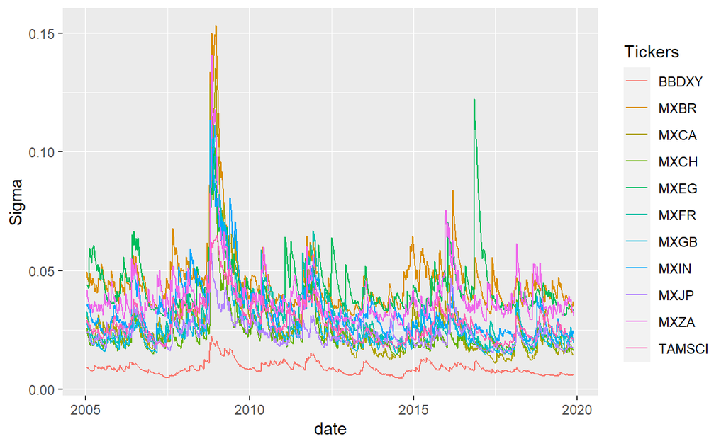

Series Volatility

```r
Vol_series <- DCCPre$marVol
colnames(Vol_series) <- colnames(xts_rtn)
library(dplyr)
Vol_series <-
  data.frame( cbind( date = index(xts_rtn), Vol_series)) %>% # Add date column which dropped away...
  mutate(date = as.Date(date)) %>%  tbl_df()  # make date column a date column...
TidyVol <- Vol_series %>% gather(Tickers, Sigma, -date) # dccPre fits the univariate GARCH models (Vol series) to each series of returns
g <-
ggplot(TidyVol) + geom_line(aes(x = date, y = Sigma, colour = Tickers))

print(g)# However the plot will be inserted in the Appedix in the actual paper for cleanliness
```

The following code chunks use the standardised residuals to estimate the time-varying conditional correlations between USD and EM-DM equity returns:

```r
#==============================================================================
### Estimating DCC model
#=============================================================================

#WE firstly save the standardized residuals (Etas) from the Vol series above

StdRes <- DCCPre$sresi

#detach tidyr and dplyr packages to avoid ambiguity between stats::filter and dplyr::filter
detach("package:tidyverse", unload=TRUE)
detach("package:tbl2xts", unload=TRUE)
#run the dccFit to calculate DCC using the starndadised residuals

DCC <- dccFit(StdRes, type="Engle")
```

```
## Estimates:  0.95 0.01610896 13.05382
## st.errors:  0.01079663 0.002560524 1.18283
## t-values:   87.99045 6.291273 11.03609
```

```r
#reload packages

pacman::p_load("tidyverse", "tbl2xts", "broom")

##calculating bivariate correlation between pairs

#plot all the bivariate time-varying correlations with BBDXY
Rhot <- DCC$rho.t

#Loop to clean plot by create a renaming function(katzke 2020)
ReturnSeries = xts_rtn
DCC.TV.Cor = Rhot

#To clean the plot
renamingdcc <- function(ReturnSeries, DCC.TV.Cor) {

  ncolrtn <- ncol(ReturnSeries)
  namesrtn <- colnames(ReturnSeries)
  paste(namesrtn, collapse = "_")

  nam <- c()
  xx <- mapply(rep, times = ncolrtn:1, x = namesrtn)
  # Now we create a nested for loop to save the names corresponding to the columns of interest..

   nam <- c()
  for (j in 1:(ncolrtn)) {
    for (i in 1:(ncolrtn)) {
      nam[(i + (j-1)*(ncolrtn))] <- paste(xx[[j]][1], xx[[i]][1], sep="_")
    }
  }

  colnames(DCC.TV.Cor) <- nam

  # So to plot all the time-varying correlations wrt BBDXY

  # First append the date column that has (again) been removed...

  DCC.TV.Cor <-
    data.frame( cbind( date = index(ReturnSeries), DCC.TV.Cor)) %>% # Add date column which dropped away...
    mutate(date = as.Date(date)) %>%  tbl_df()

  DCC.TV.Cor <- DCC.TV.Cor %>% gather(Pairs, Rho, -date)

  DCC.TV.Cor

}

#Now run the function
Rhot <-
  renamingdcc(ReturnSeries = xts_rtn, DCC.TV.Cor = Rhot)

head(Rhot %>% arrange(date))
```

```
## # A tibble: 6 x 3
##   date       Pairs       Rho
##   <date>     <chr>     <dbl>
## 1 2005-01-14 MXBR_MXBR 1
## 2 2005-01-14 MXBR_MXCA 0.674
## 3 2005-01-14 MXBR_MXCH 0.568
## 4 2005-01-14 MXBR_MXFR 0.621
## 5 2005-01-14 MXBR_MXGB 0.645
## 6 2005-01-14 MXBR_MXIN 0.511
```

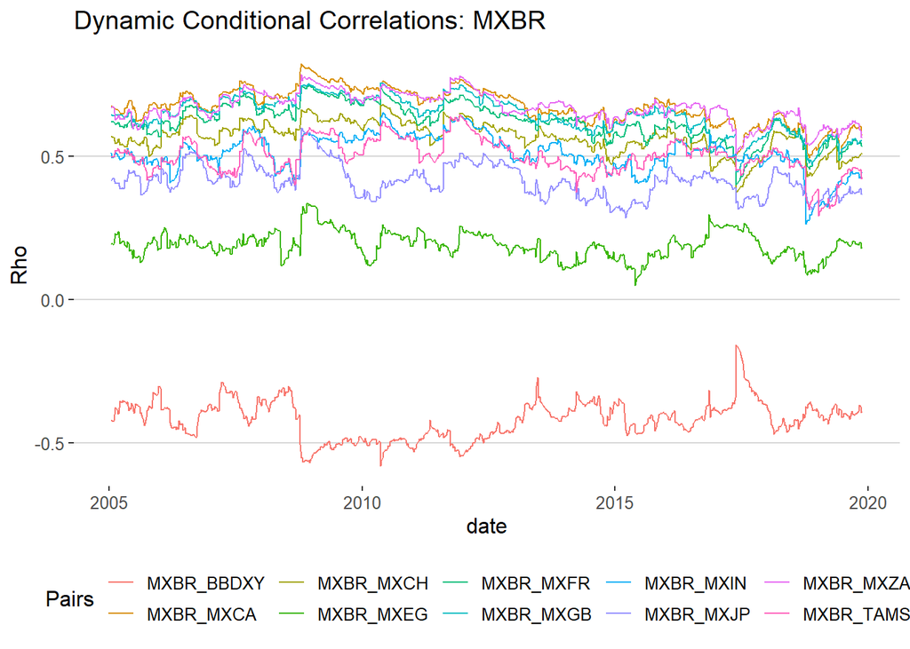

```r
  ## create a plot for all the stocks relative to the other stocks

g1 <-
    ggplot(Rhot %>% filter(grepl("MXBR_", Pairs ), !grepl("_MXBR", Pairs)) ) +
    geom_line(aes(x = date, y = Rho, colour = Pairs)) +
    theme_hc() +
    ggtitle("Dynamic Conditional Correlations: MXBR")

print(g1)
```

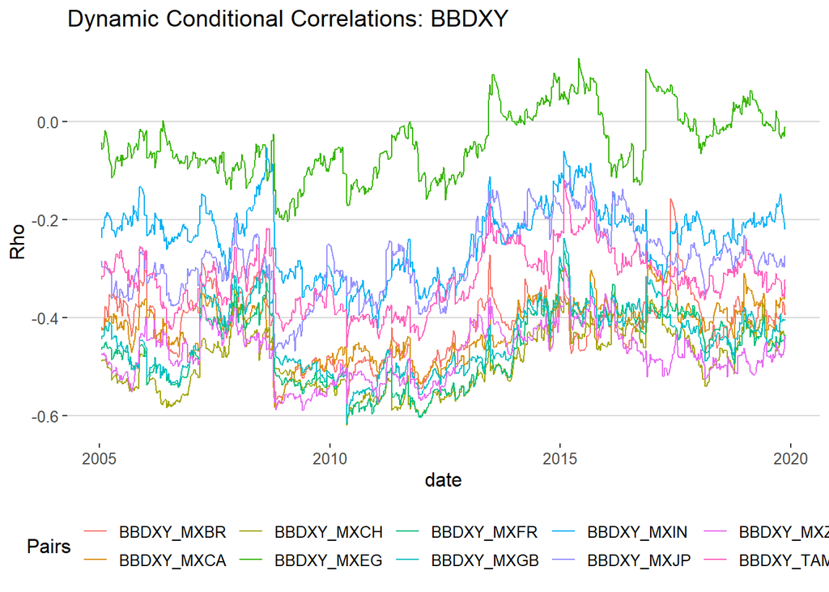

```r
## However the paper only captures code and subsequent plot for the BBDXY relative to all the stocks as set out in the objective
g2 <-
    g1 %+% subset(Rhot %>% filter(grepl("BBDXY_", Pairs ), !grepl("_BBDXY", Pairs))) + ggtitle("Dynamic Conditional Correlations: BBDXY") #(However the plot will be inserted in the Appedix in the actual paper for cleanliness)

print(g2)
```

## Appendix

As part of the data analysis a summary stattistics table is included

```r
#The following code designs a summary statistics and filters out less important stats

pacman::p_load("psych")
rtn_tbl<-rtn
rtn_tbl$Date <- NULL
rtn_tbl$scaledret <- NULL
rtn_tbl$TRI <-NULL
des_table <- psych::describeBy(rtn_tbl, rtn_tbl$Tickers, mat = TRUE)
des_table$item <- NULL
des_table$range <- NULL
des_table$mad <- NULL
des_table$n <- NULL
des_table$Date<-NULL
des_table$vars<-NULL
des_table <- des_table[ -(1:11), ]
table <- xtable(des_table, caption = "Descriptive Statistics Table \\label{tab2}")
print.xtable(table,
             tabular.environment = "longtable",
             floating = TRUE,
             table.placement = 'H',
             scalebox = 0,
             comment = FALSE,
             caption.placement = 'bottom'
)
```

```
## \scalebox{0}{
## \begin{longtable}{rlrrrrrrrrr}
##   \hline
##  & group1 & mean & sd & median & trimmed & min & max & skew & kurtosis & se \\
##   \hline
## dlogret1 & BBDXY & 0.00 & 0.01 & 0.00 & 0.00 & -0.04 & 0.04 & 0.26 & 1.77 & 0.00 \\
##   dlogret2 & MXBR & 0.00 & 0.05 & 0.01 & 0.00 & -0.33 & 0.26 & -0.45 & 5.92 & 0.00 \\
##   dlogret3 & MXCA & 0.00 & 0.03 & 0.00 & 0.00 & -0.26 & 0.18 & -1.17 & 10.69 & 0.00 \\
##   dlogret4 & MXCH & 0.00 & 0.03 & 0.00 & 0.00 & -0.25 & 0.13 & -1.53 & 14.67 & 0.00 \\
##   dlogret5 & MXEG & 0.00 & 0.04 & 0.00 & 0.00 & -0.37 & 0.15 & -1.45 & 9.59 & 0.00 \\
##   dlogret6 & MXFR & 0.00 & 0.03 & 0.00 & 0.00 & -0.27 & 0.14 & -1.12 & 8.10 & 0.00 \\
##   dlogret7 & MXGB & 0.00 & 0.03 & 0.00 & 0.00 & -0.28 & 0.17 & -1.35 & 13.84 & 0.00 \\
##   dlogret8 & MXIN & 0.00 & 0.04 & 0.00 & 0.00 & -0.22 & 0.18 & -0.45 & 3.82 & 0.00 \\
##   dlogret9 & MXJP & 0.00 & 0.02 & 0.00 & 0.00 & -0.16 & 0.09 & -0.64 & 3.61 & 0.00 \\
##   dlogret10 & MXZA & 0.00 & 0.04 & 0.00 & 0.00 & -0.20 & 0.29 & 0.09 & 4.43 & 0.00 \\
##   dlogret11 & TAMSCI & 0.00 & 0.03 & 0.00 & 0.00 & -0.12 & 0.10 & -0.52 & 1.53 & 0.00 \\
##    \hline
## \hline
## \caption{Descriptive Statistics Table \label{tab2}}
## \end{longtable}
```